# Development banks

Manh Cuong

2025-06-13

# Introduction

This dataset offers an overview of the financial and operational metrics of 17 development banks globally, covering the period from 2016 to 2024. It includes key indicators that provide insights into the financial stability, operational efficiency, and sectoral trends within the development banking sector.

The principal financial metrics included in the dataset are as follows:

- **Return on Average Assets (ROAA)**: This metric measures profitability relative to total assets, reflecting the efficiency with which a bank utilises its assets.
- **Return on Average Equity (ROAE)**: This indicator evaluates profitability from the perspective of shareholders, demonstrating the bank’s capability to generate returns on invested equity.
- **Net Interest Margin (NIM)**: This metric assesses the efficiency of a bank’s interest-earning assets in relation to its funding costs.

# Library

```r
library(readxl)
library(tidyr)
library(tidyverse)
library(dplyr)
library(knitr)
library(purrr)
library(psych)
library(ggplot2)
library(cowplot)
library(mice)
library(VIM)
library(corrplot)
library(plm)
library(AER)
library(stargazer)
library(lmtest)
library(sandwich)
```

# Preprocessing

## Import data

To begin the analysis effectively, the first and most critical step involves organising the dataset to ensure consistency and usability. Below is a detailed guide for entering all the data and unifying the table format.

### Development banks

```r
bank_names = c(
  "African Development Bank",
  "African Export-Import Bank (MUSE:AEIB.N0004)",
  "Asian Development Bank",
  "Asian Infrastructure Investment Bank",
  "Caribbean Development Bank",
  "Council of Europe Development Bank",
  "East African Development Bank",
  "ECOWAS Bank for Investment and Development",
  "Eurasian Development Bank",
  "European Bank for Reconstruction and Development",
  "European Investment Bank",
  "Inter-American Development Bank",
  "International Investment Bank",
  "Islamic Development Bank",
  "New Development Bank",
  "Nordic Investment Bank",
  "North American Development Bank"
  )

year_names = as.character(2024:2000)
```

### Reformat dataset

All the data are currently in a wide format, and I am transforming it into a longitudinal format, also referred to as panel data, for analytical purposes.

### Merging

Following this previous step, I merge all datasets to create a comprehensive and unified dataset for analysis.

Recognise missing values and denote to NA

### Overview of the Dataset

As a new step in the preprocessing phase, I will conduct an overview of the dataset to assess its structure, completeness, and relevance. This step ensures that the dataset is well-understood before proceeding with further analysis.

- Column names

```r
data = data %>%
  rename(
    CAR  = CAR,
    CCE  = `Cash and cash equivalent`,
    CIR  = `Cost to income`,
    LLP  = `Loan loss provision`,
    NCL  = `Net customer loan`,
    NFI  = `Net fee and commission income`,
    NIT  = `Net income be4 tax`,
    NII  = `Net interest income`,
    NIM  = NIM,
    NPL  = NPL,
    PLP  = `Provision to loan problem`,
    ROAA = ROAA,
    ROAE = ROAE,
    T1   = `Tier 1 ratio`,
    TA   = `Total asset`,
    DEB  = `Total debt`,
    TD   = `Total deposit`,
    TE   = `Total equity`,
    REV  = `Total revenue`
  )
```

- Data types

```r
str(data)
```

```
## tibble [425 × 22] (S3: tbl_df/tbl/data.frame)
##  $ Bank : chr [1:425] "African Development Bank" "African Development Bank" "African Development Bank" "African Development Bank" ...
##  $ Group: chr [1:425] "Africa" "Africa" "Africa" "Africa" ...
##  $ Year : chr [1:425] "2024" "2023" "2022" "2021" ...
##  $ CAR  : num [1:425] NA NA NA NA NA NA NA NA NA NA ...
##  $ CCE  : num [1:425] NA NA NA NA NA NA NA NA NA NA ...
##  $ CIR  : num [1:425] 41.2 27.5 42.1 63.8 43 ...
##  $ LLP  : num [1:425] -7332 26299 128656 35796 83046 ...
##  $ NCL  : num [1:425] 30895718 29544660 27541515 28134162 30022718 ...
##  $ NFI  : num [1:425] 53233 29198 19097 30114 26182 ...
##  $ NIT  : num [1:425] 470426 541660 320188 137505 276433 ...
##  $ NII  : num [1:425] 570661 468144 465221 594630 537512 ...
##  $ NIM  : num [1:425] 1.1 0.944 0.967 1.193 1.116 ...
##  $ NPL  : num [1:425] 2 3.02 3.29 3.29 2.75 ...
##  $ PLP  : num [1:425] 103.7 106 103.9 82.4 84.6 ...
##  $ ROAA : num [1:425] 0.606 0.927 0.47 0.114 0.395 ...
##  $ ROAE : num [1:425] 2.16 3.48 1.89 0.51 1.84 ...
##  $ T1   : num [1:425] NA NA NA NA NA NA NA NA NA NA ...
##  $ TA   : num [1:425] 55389477 52953841 50865124 50838700 50910130 ...
##  $ DEB  : num [1:425] 34462151 33263258 32296179 35163588 36155231 ...
##  $ TD   : num [1:425] 0 0 0 0 0 0 0 0 0 0 ...
##  $ TE   : num [1:425] 15957478 14508954 13152028 12184309 11220245 ...
##  $ REV  : num [1:425] 787914 782623 770984 479500 635169 ...
```

- Duplicates

```r
sum(duplicated(data))
```

```
## [1] 0
```

- Missing values

```r
sapply(data, function(x) sum(is.na(x)))
```

```
##  Bank Group  Year   CAR   CCE   CIR   LLP   NCL   NFI   NIT   NII   NIM   NPL
##     0     0     0   302   114   176    91    94   229    85    95   175   200
##   PLP  ROAA  ROAE    T1    TA   DEB    TD    TE   REV
##   232   110   110   367    84    84   169    84    85
```

## Imputing missing values

- Report NAs

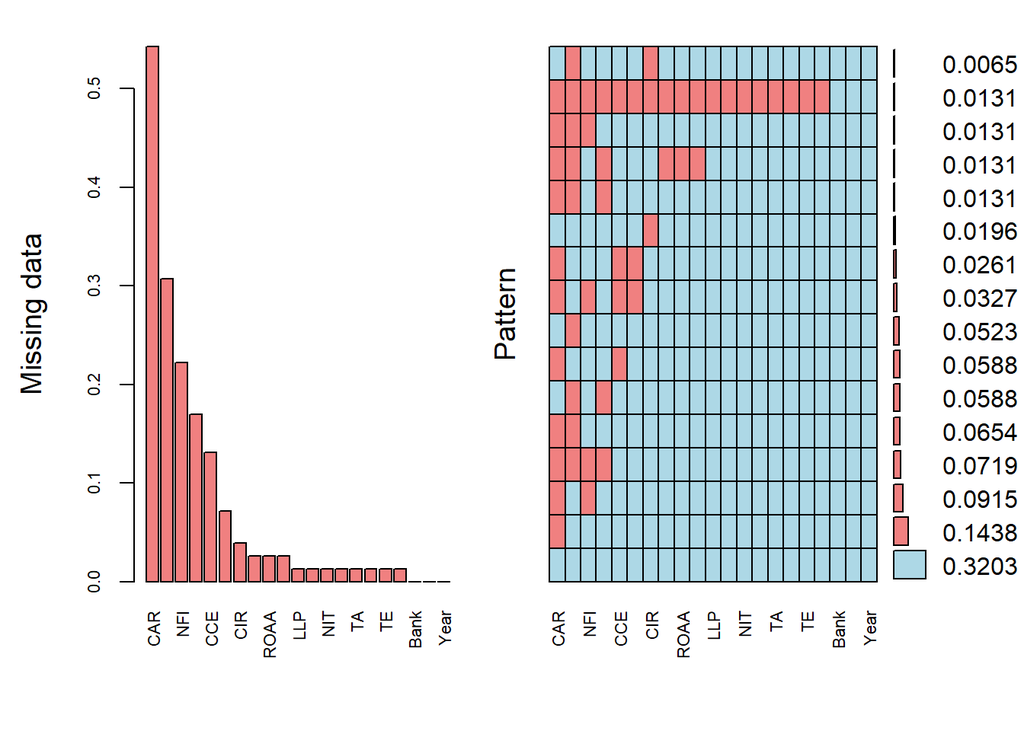

```
##
##  Variables sorted by number of missings:
##  Variable      Count
##       CAR 0.54248366
##       PLP 0.30718954
##       NFI 0.22222222
##       NPL 0.16993464
##       CCE 0.13071895
##        TD 0.07189542
##       CIR 0.03921569
##       NIM 0.02614379
##      ROAA 0.02614379
##      ROAE 0.02614379
##       LLP 0.01307190
##       NCL 0.01307190
##       NIT 0.01307190
##       NII 0.01307190
##        TA 0.01307190
##       DEB 0.01307190
##        TE 0.01307190
##       REV 0.01307190
##      Bank 0.00000000
##     Group 0.00000000
##      Year 0.00000000
```

```r
aggr_plot = aggr(data, col=c('lightblue', 'lightcoral'),
                 numbers=TRUE, sortVars=TRUE,
                 labels=names(data), cex.axis=0.7, gap=3,
                 ylab=c("Missing data","Pattern"))
```

- Apply Hotdeck

```r
set.seed(2610)
data_imputed = data %>%
  mutate(across(all_of(metric_cols), ~ na_if(.x, 0))) %>%
  as.data.frame() %>%
  hotdeck(
    variable   = metric_cols,
    domain_var = c("Group", "Year")
  ) %>%
  as_tibble()

data = data_imputed[,c(1:21)]

data = hotdeck(data)
data = data[,c(1:21)]
```

# Descriptive statistics

## Descriptive tables

```r
describe(data)
```

```
##        vars   n        mean           sd      median     trimmed         mad
## Bank*     1 153        9.00         4.92        9.00        9.00        5.93
## Group*    2 153        3.12         1.57        3.00        3.02        1.48
## Year*     3 153        5.00         2.59        5.00        5.00        2.97
## CAR       4 153       57.64        48.56       36.68       47.23       15.59
## CCE       5 153 14598271.55  41637599.57  1918434.00  4026059.62  2716612.46
## CIR       6 153       44.22        34.11       38.77       40.03       20.42
## LLP       7 153    49125.85    164844.89     7000.00    24321.14    21828.19
## NCL       8 153 44213037.87  90920169.75 13265953.60 20573624.15 18182249.98
## NFI       9 153    48555.06     82320.96    10316.00    30608.56    15398.28
## NIT      10 153   732348.82   2747074.97   165859.00   297573.49   234240.42
## NII      11 153   638131.70    901792.23   231005.14   446984.33   307713.84
## NIM      12 153        1.70         1.16        1.36        1.52        1.01
## NPL      13 153        2.79         2.66        2.40        2.41        2.78
## PLP      14 153      143.74       149.64       92.47      111.25       64.72
## ROAA     15 153        0.95         1.92        0.62        0.86        0.53
## ROAE     16 153        3.40         7.10        2.61        2.88        1.90
## TA       17 153 81096792.78 162566301.36 28576225.98 37583111.99 39231987.41
## DEB      18 153 55217561.53 124478207.51 14781000.00 23420206.54 20988594.24
## TD       19 153  1899195.45   2592266.52   307507.00  1347959.91   443869.40
## TE       20 153 15443658.49  22369829.76  4807749.53 10291257.61  6714399.67
## REV      21 153  1085108.87   2917448.35   305630.28   578674.43   424962.51
##                min          max        range skew kurtosis          se
## Bank*         1.00        17.00        16.00 0.00    -1.23        0.40
## Group*        1.00         6.00         5.00 0.44    -0.80        0.13
## Year*         1.00         9.00         8.00 0.00    -1.25        0.21
## CAR          22.52       232.90       210.38 1.86     2.43        3.93
## CCE        8087.68 205086244.65 205078156.97 3.69    12.19  3366200.41
## CIR           1.83       358.43       356.60 5.39    44.98        2.76
## LLP     -344877.17   1492823.01   1837700.19 5.11    38.30    13326.92
## NCL        9553.00 422487713.76 422478160.76 2.96     8.07  7350460.07
## NFI       -5143.84    480339.22    485483.06 2.82     9.77     6655.26
## NIT    -1176770.15  31522000.00  32698770.15 9.49   101.04   222087.85
## NII        5315.46   3782562.86   3777247.40 1.89     3.00    72905.58
## NIM           0.15         5.64         5.49 1.24     0.96        0.09
## NPL           0.04        15.36        15.32 1.34     2.38        0.22
## PLP          12.31       729.21       716.90 2.14     4.32       12.10
## ROAA         -7.24        18.50        25.75 4.28    46.46        0.16
## ROAE        -28.04        69.40        97.44 4.50    49.45        0.57
## TA       366832.00 767027011.62 766660179.62 3.00     8.24 13142706.50
## DEB       75795.00 593298162.69 593222367.69 3.33    10.26 10063466.62
## TD         4422.82  10178933.00  10174510.18 1.62     1.76   209572.33
## TE       251167.00  98393339.23  98142172.23 2.08     3.85  1808493.55
## REV      -68306.00  32149000.00  32217306.00 8.28    82.21   235861.72
```

## Visualisation

- Numbers of banks by Geography

Number of Development Banks by Geography

| Geography | Number_of_Banks |
| --- | --- |
| Africa | 3 |
| Asia-Pacific | 3 |
| Europe | 6 |
| Latin America and Caribbean | 1 |
| Middle East | 2 |
| United States and Canada | 2 |

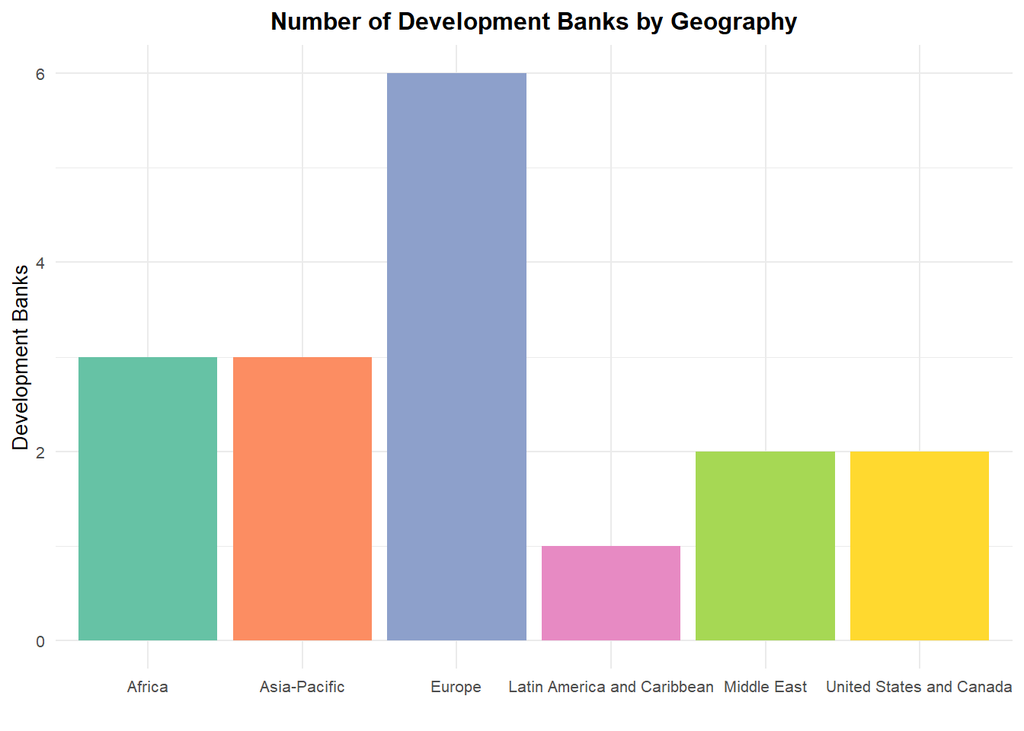

- Targets: ROA, ROE, NIM by Geography

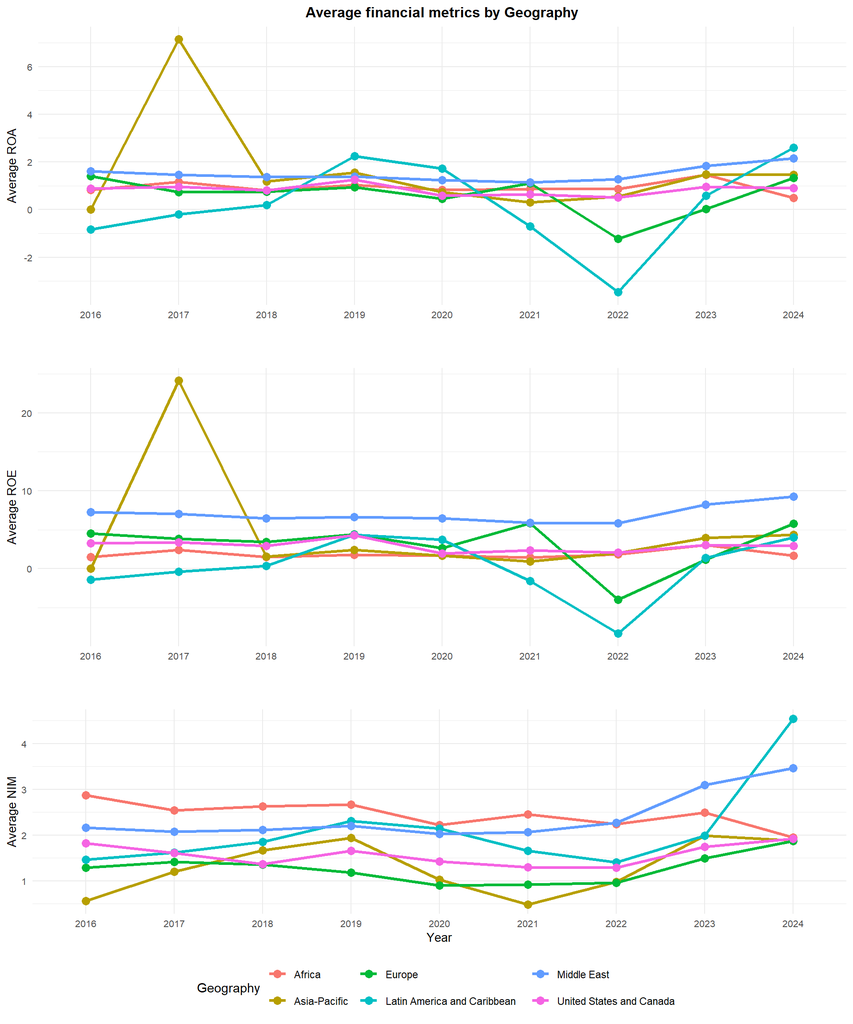

## Histogram

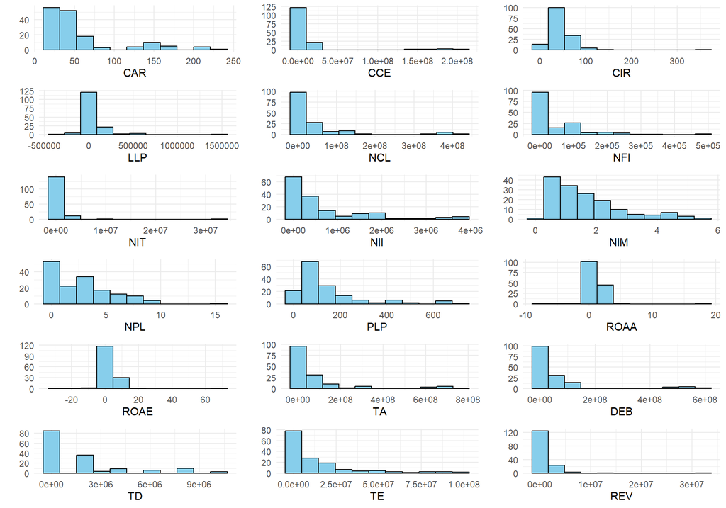

# Transformed data

```r
data = data %>%
  mutate(
    # Capital structure
    CAR   = CAR,

    # Asset quality
    NPL   = NPL,

    # Provision
    LLPr  = LLP / NCL,

    # Efficiency
    CIR   = CIR,
    REV   = (REV - mean(REV))/sd(REV),
    NIIr  = NII / TA,

    # Liquidity
    LIQr  = CCE / TA,
    LDR   = NCL / TD,
    ETA   = TE  / TA,

    # Size
    Size  = log(TA),

    # Dependents
    ROAA  = ROAA,
    ROAE  = ROAE,
    NIM   = NIM
  ) %>%
  select(
    Bank, Group, Year,
    CAR,
    NPL,
    LLPr,
    CIR,  REV,  NIIr,
    LIQr, LDR,  ETA,
    Size,
    ROAA, ROAE, NIM
  )
```

## Descriptive statistics

```r
describe(data)
```

```
##        vars   n   mean     sd median trimmed   mad    min     max   range  skew
## Bank*     1 153   9.00   4.92   9.00    9.00  5.93   1.00   17.00   16.00  0.00
## Group*    2 153   3.12   1.57   3.00    3.02  1.48   1.00    6.00    5.00  0.44
## Year*     3 153   5.00   2.59   5.00    5.00  2.97   1.00    9.00    8.00  0.00
## CAR       4 153  57.64  48.56  36.68   47.23 15.59  22.52  232.90  210.38  1.86
## NPL       5 153   2.79   2.66   2.40    2.41  2.78   0.04   15.36   15.32  1.34
## LLPr      6 153   0.00   0.01   0.00    0.00  0.00  -0.04    0.05    0.09  2.04
## CIR       7 153  44.22  34.11  38.77   40.03 20.42   1.83  358.43  356.60  5.39
## REV       8 153   0.00   1.00  -0.27   -0.17  0.15  -0.40   10.65   11.04  8.28
## NIIr      9 153   0.02   0.01   0.01    0.01  0.01   0.00    0.05    0.05  1.20
## LIQr     10 153   0.20   0.16   0.17    0.18  0.16   0.00    0.67    0.67  0.74
## LDR      11 153 268.51 898.31  15.57   55.41 22.71   0.00 5918.56 5918.55  4.63
## ETA      12 153   0.34   0.21   0.29    0.31  0.16   0.10    1.00    0.90  1.36
## Size     13 153  16.62   2.03  17.17   16.62  2.20  12.81   20.46    7.65 -0.14
## ROAA     14 153   0.95   1.92   0.62    0.86  0.53  -7.24   18.50   25.75  4.28
## ROAE     15 153   3.40   7.10   2.61    2.88  1.90 -28.04   69.40   97.44  4.50
## NIM      16 153   1.70   1.16   1.36    1.52  1.01   0.15    5.64    5.49  1.24
##        kurtosis    se
## Bank*     -1.23  0.40
## Group*    -0.80  0.13
## Year*     -1.25  0.21
## CAR        2.43  3.93
## NPL        2.38  0.22
## LLPr       7.68  0.00
## CIR       44.98  2.76
## REV       82.21  0.08
## NIIr       0.79  0.00
## LIQr      -0.09  0.01
## LDR       21.61 72.62
## ETA        1.64  0.02
## Size      -0.89  0.16
## ROAA      46.46  0.16
## ROAE      49.45  0.57
## NIM        0.96  0.09
```

## Correlation matrix

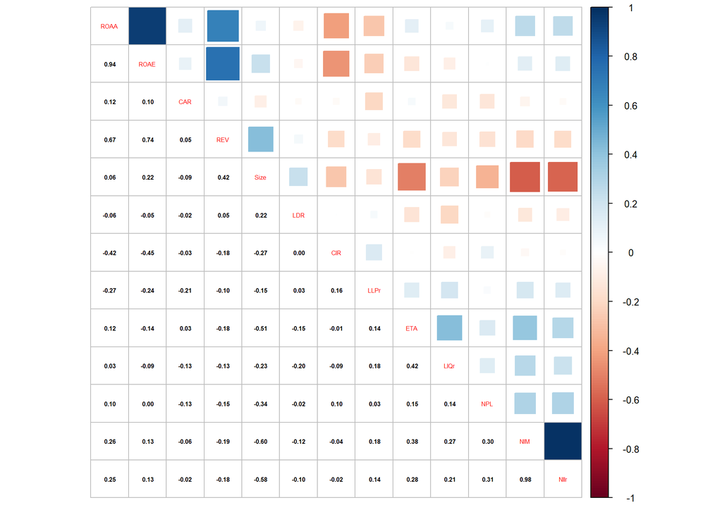

# Model evaluation

## Set up Panel data

```r
pdata = pdata.frame(data,index = c("Bank","Year"))
```

## ROAA

### Pool OLS

```r
ols_ROA = plm(ROAA ~ CAR +
                     NPL +
                     LLPr +
                     CIR + REV + NIIr +
                     LIQr + LDR + ETA +
                     Size +
                     Group, data = pdata,
                     model = 'pooling',
                     effect = 'twoways')
```

### FEM

```r
fem_ROA = plm(ROAA ~ CAR +
                     NPL +
                     LLPr +
                     CIR + REV + NIIr +
                     LIQr + LDR + ETA +
                     Size +
                     Group, data = pdata,
                     index = c('Bank', 'Year'),
                     model = 'within',
                     effect = 'twoways')
```

### REM

```r
rem_ROA = plm(ROAA ~ CAR +
                     NPL +
                     LLPr +
                     CIR + REV + NIIr +
                     LIQr + LDR + ETA +
                     Size +
                     Group, data = pdata,
                     index = c('Bank', 'Year'),
                     model = 'random',
                     effect = 'twoways',
                     random.method = 'walhus')
```

### Hausman test

```r
phtest(fem_ROA, rem_ROA)
```

```
##
##  Hausman Test
##
## data:  ROAA ~ CAR + NPL + LLPr + CIR + REV + NIIr + LIQr + LDR + ETA +  ...
## chisq = 33.914, df = 10, p-value = 0.000191
## alternative hypothesis: one model is inconsistent
```

### Two stages least square

```r
tsls_ROA = ivreg(ROAA ~ CAR +
                        NPL +
                        LLPr +
                        CIR + REV +
                        LIQr + LDR +
                        Size +
                        Group | CAR + NPL + LLPr + CIR + REV + NIIr +
                        LDR + ETA +
                        Size + Group, data = pdata)

summary(tsls_ROA, diagnostics = TRUE,
                  vcov. = vcovHC(tsls_ROA, type = "HC1"))
```

```
##
## Call:
## ivreg(formula = ROAA ~ CAR + NPL + LLPr + CIR + REV + LIQr +
##     LDR + Size + Group | CAR + NPL + LLPr + CIR + REV + NIIr +
##     LDR + ETA + Size + Group, data = pdata)
##
## Residuals:
##      Min       1Q   Median       3Q      Max
## -6.64287 -0.37462  0.06205  0.52256  1.88263
##
## Coefficients:
##                                    Estimate Std. Error t value Pr(>|t|)
## (Intercept)                       5.234e+00  2.122e+00   2.466  0.01486 *
## CAR                               6.014e-03  2.409e-03   2.497  0.01371 *
## NPL                               1.255e-01  4.995e-02   2.513  0.01312 *
## LLPr                             -4.502e+01  1.552e+01  -2.901  0.00432 **
## CIR                              -1.532e-02  3.333e-03  -4.596 9.57e-06 ***
## REV                               1.462e+00  1.839e-01   7.949 5.81e-13 ***
## LIQr                              3.014e+00  1.282e+00   2.352  0.02007 *
## LDR                               8.430e-05  4.810e-05   1.752  0.08190 .
## Size                             -3.019e-01  1.050e-01  -2.876  0.00467 **
## GroupAsia-Pacific                 7.649e-01  3.171e-01   2.412  0.01715 *
## GroupEurope                      -1.764e-01  3.171e-01  -0.556  0.57902
## GroupLatin America and Caribbean -5.678e-01  5.034e-01  -1.128  0.26129
## GroupMiddle East                  1.457e+00  3.027e-01   4.813 3.82e-06 ***
## GroupUnited States and Canada     7.853e-01  2.666e-01   2.945  0.00379 **
##
## Diagnostic tests:
##                  df1 df2 statistic  p-value
## Weak instruments   2 138    34.446 7.33e-13 ***
## Wu-Hausman         1 138     6.823     0.01 **
## Sargan             1  NA    17.279 3.23e-05 ***
## ---
## Signif. codes:  0 '***' 0.001 '**' 0.01 '*' 0.05 '.' 0.1 ' ' 1
##
## Residual standard error: 1.004 on 139 degrees of freedom
## Multiple R-Squared: 0.7493,  Adjusted R-squared: 0.7259
## Wald test: 19.73 on 13 and 139 DF,  p-value: < 2.2e-16
```

### First stage

```r
fs_2sls = lm(LIQr ~ CAR +
                    NPL +
                    LLPr +
                    CIR + REV +
                    NIIr + LDR + ETA +
                    Size +
                    Group, data = pdata)

summary(fs_2sls)
```

```
##
## Call:
## lm(formula = LIQr ~ CAR + NPL + LLPr + CIR + REV + NIIr + LDR +
##     ETA + Size + Group, data = pdata)
##
## Residuals:
##      Min       1Q   Median       3Q      Max
## -0.30034 -0.05453 -0.01157  0.03880  0.25166
##
## Coefficients:
##                                    Estimate Std. Error t value Pr(>|t|)
## (Intercept)                      -1.051e-01  1.606e-01  -0.654  0.51418
## CAR                              -4.570e-04  2.132e-04  -2.143  0.03383 *
## NPL                              -7.845e-03  4.147e-03  -1.891  0.06066 .
## LLPr                             -6.169e-01  9.191e-01  -0.671  0.50325
## CIR                              -9.229e-05  2.952e-04  -0.313  0.75503
## REV                              -6.807e-03  1.000e-02  -0.681  0.49729
## NIIr                              3.173e+00  1.157e+00   2.744  0.00688 **
## LDR                              -8.043e-06  1.082e-05  -0.743  0.45863
## ETA                               5.301e-01  6.671e-02   7.946 6.11e-13 ***
## Size                              5.385e-03  8.254e-03   0.652  0.51524
## GroupAsia-Pacific                -2.649e-02  4.174e-02  -0.635  0.52672
## GroupEurope                       1.841e-01  3.101e-02   5.937 2.24e-08 ***
## GroupLatin America and Caribbean -1.025e-01  4.769e-02  -2.149  0.03338 *
## GroupMiddle East                  2.092e-02  3.909e-02   0.535  0.59332
## GroupUnited States and Canada    -1.139e-01  3.657e-02  -3.114  0.00225 **
## ---
## Signif. codes:  0 '***' 0.001 '**' 0.01 '*' 0.05 '.' 0.1 ' ' 1
##
## Residual standard error: 0.1099 on 138 degrees of freedom
## Multiple R-squared:  0.5843, Adjusted R-squared:  0.5421
## F-statistic: 13.85 on 14 and 138 DF,  p-value: < 2.2e-16
```

```r
vif(rem_ROA)
```

```
##           GVIF Df GVIF^(1/(2*Df))
## CAR   1.242231  1        1.114554
## NPL   1.412472  1        1.188475
## LLPr  1.187062  1        1.089524
## CIR   1.196050  1        1.093641
## REV   1.167311  1        1.080422
## NIIr  1.717628  1        1.310583
## LIQr  2.089654  1        1.445564
## LDR   1.120205  1        1.058397
## ETA   3.062559  1        1.750017
## Size  2.997367  1        1.731291
## Group 6.031235  5        1.196852
```

```r
bptest(rem_ROA)
```

```
##
##  studentized Breusch-Pagan test
##
## data:  rem_ROA
## BP = 27.466, df = 15, p-value = 0.02516
```

```r
pdwtest(rem_ROA)
```

```
##
##  Durbin-Watson test for serial correlation in panel models
##
## data:  ROAA ~ CAR + NPL + LLPr + CIR + REV + NIIr + LIQr + LDR + ETA +  ...
## DW = 1.7813, p-value = 0.01895
## alternative hypothesis: serial correlation in idiosyncratic errors
```

### Control function (Report fisrt stage only)

```r
# Mean of time varying
tvp_means = data %>%
  group_by(Bank) %>%
  summarise(
    m_CAR  = mean(CAR,  na.rm=TRUE),
    m_NPL  = mean(NPL, na.rm=TRUE),
    m_LLPr = mean(LLPr, na.rm=TRUE),
    m_CIR  = mean(CIR,  na.rm=TRUE),
    m_REV  = mean(REV,  na.rm=TRUE),
    m_NIIr = mean(NIIr, na.rm=TRUE),
    m_LIQr = mean(LIQr, na.rm=TRUE),
    m_LDR  = mean(LDR,  na.rm=TRUE),
    m_ETA  = mean(ETA,  na.rm=TRUE),
    m_Size = mean(Size, na.rm=TRUE),
    .groups = "drop"
  )

data_cre = data %>%
  left_join(tvp_means, by = "Bank")

# Set up panel
pdata_cre = pdata.frame(data_cre, index = c("Bank","Year"))

# Stage 1: CRE with LIQr is endogeneity
stage1_cre = plm(LIQr ~ CAR +
                        NPL +
                        LLPr +
                        CIR + REV +
                        LDR +
                        Size +
                        # instruments
                        NIIr + ETA +
                        # TVP means
                        m_CAR + m_NPL + m_LLPr + m_CIR + m_REV +
                        m_NIIr + m_ETA + m_LDR + m_Size +
                        # geography
                        Group,
                        data          = pdata_cre,
                        model         = "random",
                        effect        = "twoways",
                        random.method = 'walhus')
```

```r
# F-test for mean of time varying
fs1_H_null = c(
  "m_CAR = 0",
  "m_NPL = 0",
  "m_LLPr = 0",
  "m_CIR = 0",
  "m_REV = 0",
  "m_NIIr = 0",
  "m_LDR = 0",
  "m_ETA = 0",
  "m_Size = 0"
)

vc = vcovHC(stage1_cre, type = "HC1", cluster = "group")

linearHypothesis(
  stage1_cre,
  fs1_H_null,
  vcov. = vc,
  test  = "F"
)
```

```
##
## Linear hypothesis test:
## m_CAR = 0
## m_NPL = 0
## m_LLPr = 0
## m_CIR = 0
## m_REV = 0
## m_NIIr = 0
## m_LDR = 0
## m_ETA = 0
## m_Size = 0
##
## Model 1: restricted model
## Model 2: LIQr ~ CAR + NPL + LLPr + CIR + REV + LDR + Size + NIIr + ETA +
##     m_CAR + m_NPL + m_LLPr + m_CIR + m_REV + m_NIIr + m_ETA +
##     m_LDR + m_Size + Group
##
## Note: Coefficient covariance matrix supplied.
##
##   Res.Df Df     F    Pr(>F)
## 1    138
## 2    129  9 11.88 1.716e-13 ***
## ---
## Signif. codes:  0 '***' 0.001 '**' 0.01 '*' 0.05 '.' 0.1 ' ' 1
```

```r
# Stage 1: CRE with LIQr is endogeneity
stage1_cre = plm(LIQr ~ CAR +
                        NPL +
                        LLPr +
                        CIR + REV +
                        LDR +
                        Size +
                        # instruments
                        NIIr + ETA +
                        # TVP means
                        m_CAR + m_NPL + m_LLPr + m_CIR + m_REV +
                        m_NIIr + m_ETA + m_LDR + m_Size +
                        # geography
                        Group,
                        data          = pdata_cre,
                        model         = "within",
                        effect        = "twoways")
summary(
  stage1_cre,
  vcov = function(x) vcovHC(x, type="HC1", cluster="group"),
  doFit = TRUE
)
```

```
## Twoways effects Within Model
##
## Note: Coefficient variance-covariance matrix supplied: function(x) vcovHC(x, type = "HC1", cluster = "group")
##
## Call:
## plm(formula = LIQr ~ CAR + NPL + LLPr + CIR + REV + LDR + Size +
##     NIIr + ETA + m_CAR + m_NPL + m_LLPr + m_CIR + m_REV + m_NIIr +
##     m_ETA + m_LDR + m_Size + Group, data = pdata_cre, effect = "twoways",
##     model = "within")
##
## Balanced Panel: n = 17, T = 9, N = 153
##
## Residuals:
##       Min.    1st Qu.     Median    3rd Qu.       Max.
## -0.1922318 -0.0288232 -0.0027169  0.0230231  0.3339755
##
## Coefficients:
##         Estimate  Std. Error t-value  Pr(>|t|)
## CAR  -5.9942e-05  1.0529e-04 -0.5693   0.57022
## NPL  -9.4939e-03  4.4590e-03 -2.1291   0.03530 *
## LLPr  1.0647e+00  4.5901e-01  2.3196   0.02207 *
## CIR  -8.9736e-05  2.0329e-04 -0.4414   0.65972
## REV  -5.3413e-03  2.7880e-03 -1.9158   0.05778 .
## LDR  -6.0738e-06  5.5518e-06 -1.0940   0.27615
## Size -1.5766e-01  3.5327e-02 -4.4628 1.849e-05 ***
## NIIr  2.5975e+00  1.0877e+00  2.3881   0.01851 *
## ETA   1.4748e-01  6.2362e-02  2.3649   0.01965 *
## ---
## Signif. codes:  0 '***' 0.001 '**' 0.01 '*' 0.05 '.' 0.1 ' ' 1
##
## Total Sum of Squares:    1.0209
## Residual Sum of Squares: 0.59716
## R-Squared:      0.41509
## Adj. R-Squared: 0.25288
## F-statistic: 22.1822 on 9 and 16 DF, p-value: 2.1115e-07
```

```r
# Residuals
pdata_cre$e_hat = residuals(stage1_cre)

# Stage 2: CRE with e_hat
cf_ROA = plm(ROAA ~ e_hat + LIQr +
                        CAR +
                        NPL +
                        LLPr +
                        CIR + REV +
                        LDR +
                        Size +
                        m_CAR + m_NPL + m_LLPr + m_CIR + m_REV +
                        m_LIQr + m_LDR + m_Size +
                        Group,
                        data          = pdata_cre,
                        model         = "within",
                        effect        = "twoways")
```

## ROAE

### Pool OLS

```r
ols_ROE = plm(ROAE ~ CAR +
                     NPL +
                     LLPr +
                     CIR + REV + NIIr +
                     LIQr + LDR + ETA +
                     Size +
                     Group,
                     data   = pdata,
                     model  = "pooling",
                     effect = "twoways")
```

### FEM

```r
fem_ROE = plm(ROAE ~ CAR +
                     NPL +
                     LLPr +
                     CIR + REV + NIIr +
                     LIQr + LDR + ETA +
                     Size +
                     Group,
                     data   = pdata,
                     index  = c("Bank","Year"),
                     model  = "within",
                     effect = "twoways")
```

### REM

```r
rem_ROE = plm(ROAE ~ CAR +
                     NPL +
                     LLPr +
                     CIR + REV + NIIr +
                     LIQr + LDR + ETA +
                     Size +
                     Group,
                     data          = pdata,
                     index         = c("Bank","Year"),
                     model         = "random",
                     effect        = "twoways",
                     random.method = "walhus")
```

### Hausman test

```r
phtest(fem_ROE, rem_ROE)
```

```
##
##  Hausman Test
##
## data:  ROAE ~ CAR + NPL + LLPr + CIR + REV + NIIr + LIQr + LDR + ETA +  ...
## chisq = 200.43, df = 10, p-value < 2.2e-16
## alternative hypothesis: one model is inconsistent
```

### Two stages least square

```r
tsls_ROE = ivreg(ROAE ~ CAR +
                        NPL +
                        LLPr +
                        CIR + REV +
                        LIQr + LDR +
                        Size +
                        Group | CAR + NPL + LLPr + CIR + REV + NIIr +
                        LDR + ETA + Size + Group, data = pdata)

summary(
  tsls_ROE,
  diagnostics = TRUE,
  vcov.       = sandwich::vcovHC(tsls_ROE, type="HC1")
)
```

```
##
## Call:
## ivreg(formula = ROAE ~ CAR + NPL + LLPr + CIR + REV + LIQr +
##     LDR + Size + Group | CAR + NPL + LLPr + CIR + REV + NIIr +
##     LDR + ETA + Size + Group, data = pdata)
##
## Residuals:
##     Min      1Q  Median      3Q     Max
## -27.969  -1.341   0.265   1.422   6.548
##
## Coefficients:
##                                    Estimate Std. Error t value Pr(>|t|)
## (Intercept)                       2.284e+01  8.331e+00   2.741  0.00693 **
## CAR                               1.270e-02  7.431e-03   1.709  0.08966 .
## NPL                               2.234e-01  1.811e-01   1.233  0.21962
## LLPr                             -1.265e+02  5.289e+01  -2.392  0.01807 *
## CIR                              -6.862e-02  1.365e-02  -5.026 1.52e-06 ***
## REV                               5.437e+00  5.426e-01  10.021  < 2e-16 ***
## LIQr                             -4.814e+00  4.637e+00  -1.038  0.30103
## LDR                               2.014e-05  9.879e-05   0.204  0.83874
## Size                             -1.076e+00  3.984e-01  -2.701  0.00778 **
## GroupAsia-Pacific                 1.868e+00  7.549e-01   2.475  0.01452 *
## GroupEurope                       1.830e+00  1.081e+00   1.694  0.09258 .
## GroupLatin America and Caribbean -2.524e+00  1.334e+00  -1.892  0.06054 .
## GroupMiddle East                  6.693e+00  1.080e+00   6.198 6.10e-09 ***
## GroupUnited States and Canada     6.873e-01  7.759e-01   0.886  0.37730
##
## Diagnostic tests:
##                  df1 df2 statistic  p-value
## Weak instruments   2 138    34.446 7.33e-13 ***
## Wu-Hausman         1 138     0.443    0.507
## Sargan             1  NA    18.702 1.53e-05 ***
## ---
## Signif. codes:  0 '***' 0.001 '**' 0.01 '*' 0.05 '.' 0.1 ' ' 1
##
## Residual standard error: 3.486 on 139 degrees of freedom
## Multiple R-Squared: 0.7797,  Adjusted R-squared: 0.7591
## Wald test: 23.17 on 13 and 139 DF,  p-value: < 2.2e-16
```

### Diagnostic

```r
vif(rem_ROE)
```

```
##           GVIF Df GVIF^(1/(2*Df))
## CAR   1.188815  1        1.090328
## NPL   1.341391  1        1.158184
## LLPr  1.161173  1        1.077578
## CIR   1.171586  1        1.082398
## REV   1.137717  1        1.066638
## NIIr  1.629824  1        1.276646
## LIQr  1.973629  1        1.404859
## LDR   1.099028  1        1.048345
## ETA   2.816445  1        1.678227
## Size  2.795816  1        1.672070
## Group 4.806536  5        1.169993
```

```r
bptest(rem_ROE)
```

```
##
##  studentized Breusch-Pagan test
##
## data:  rem_ROE
## BP = 20.245, df = 15, p-value = 0.1627
```

```r
pdwtest(rem_ROE)
```

```
##
##  Durbin-Watson test for serial correlation in panel models
##
## data:  ROAE ~ CAR + NPL + LLPr + CIR + REV + NIIr + LIQr + LDR + ETA +  ...
## DW = 1.7099, p-value = 0.006183
## alternative hypothesis: serial correlation in idiosyncratic errors
```

### Control function

```r
cf_ROE = plm(ROAE ~ e_hat + LIQr +
                        CAR +
                        NPL +
                        LLPr +
                        CIR + REV +
                        LDR +
                        Size +
                        m_CAR + m_NPL + m_LLPr + m_CIR + m_REV +
                        m_LIQr + m_LDR + m_Size +
                        Group,
                        data   = pdata_cre,
                        model  = "within",
                        effect = "twoways")
```

## NIM

### Pool OLS

```r
ols_NIM = plm(NIM ~ CAR +
                     NPL +
                     LLPr +
                     CIR + REV + NIIr +
                     LIQr + LDR + ETA + Size + Group,
                     data   = pdata,
                     model  = "pooling",
                     effect = "twoways")
```

### FEM

```r
fem_NIM = plm(NIM ~ CAR +
                     NPL +
                     LLPr +
                     CIR + REV + NIIr +
                     LIQr + LDR + ETA + Size + Group,
                     data   = pdata,
                     index  = c("Bank","Year"),
                     model  = "within",
                     effect = "twoways")
```

### REM

```r
rem_NIM = plm(NIM ~ CAR +
                    NPL +
                    LLPr +
                    CIR + REV + NIIr +
                    LIQr + LDR + ETA +
                    Size +
                    Group,
                    data          = pdata,
                    index         = c("Bank","Year"),
                    model         = "random",
                    effect        = "twoways",
                    random.method = "walhus")
```

### Hausman test

```r
phtest(fem_NIM, rem_NIM)
```

```
##
##  Hausman Test
##
## data:  NIM ~ CAR + NPL + LLPr + CIR + REV + NIIr + LIQr + LDR + ETA +  ...
## chisq = 10.813, df = 10, p-value = 0.3723
## alternative hypothesis: one model is inconsistent
```

### 2SLS

```r
tsls_NIM = ivreg(NIM ~ CAR +
                       NPL +
                       LLPr +
                       CIR + REV +
                       LIQr + LDR +
                       Size +
                       Group | CAR + NPL + LLPr + CIR + REV + NIIr +
                       LDR + ETA + Size + Group, data = pdata)

summary(tsls_NIM,
        diagnostics = TRUE,
        vcov.       = sandwich::vcovHC(tsls_NIM, type="HC1"))
```

```
##
## Call:
## ivreg(formula = NIM ~ CAR + NPL + LLPr + CIR + REV + LIQr + LDR +
##     Size + Group | CAR + NPL + LLPr + CIR + REV + NIIr + LDR +
##     ETA + Size + Group, data = pdata)
##
## Residuals:
##      Min       1Q   Median       3Q      Max
## -1.61654 -0.52909 -0.04966  0.46146  3.33077
##
## Coefficients:
##                                    Estimate Std. Error t value Pr(>|t|)
## (Intercept)                       5.022e+00  9.467e-01   5.305 4.34e-07 ***
## CAR                               1.350e-03  1.355e-03   0.996   0.3209
## NPL                               2.840e-02  3.351e-02   0.848   0.3981
## LLPr                              8.104e+00  1.157e+01   0.700   0.4849
## CIR                              -5.178e-03  3.524e-03  -1.469   0.1440
## REV                               1.081e-01  5.946e-02   1.819   0.0711 .
## LIQr                              4.211e+00  9.538e-01   4.415 2.02e-05 ***
## LDR                               7.893e-05  4.278e-05   1.845   0.0672 .
## Size                             -2.256e-01  4.560e-02  -4.947 2.14e-06 ***
## GroupAsia-Pacific                -7.302e-01  2.998e-01  -2.435   0.0161 *
## GroupEurope                      -1.018e+00  2.391e-01  -4.257 3.79e-05 ***
## GroupLatin America and Caribbean -5.631e-02  2.185e-01  -0.258   0.7970
## GroupMiddle East                  4.516e-01  3.743e-01   1.207   0.2297
## GroupUnited States and Canada     2.531e-01  2.218e-01   1.141   0.2558
##
## Diagnostic tests:
##                  df1 df2 statistic  p-value
## Weak instruments   2 138     34.45 7.33e-13 ***
## Wu-Hausman         1 138     15.00 0.000165 ***
## Sargan             1  NA    110.69  < 2e-16 ***
## ---
## Signif. codes:  0 '***' 0.001 '**' 0.01 '*' 0.05 '.' 0.1 ' ' 1
##
## Residual standard error: 0.902 on 139 degrees of freedom
## Multiple R-Squared: 0.4475,  Adjusted R-squared: 0.3958
## Wald test: 26.66 on 13 and 139 DF,  p-value: < 2.2e-16
```

### Diagnostic

```r
vif(rem_NIM)
```

```
##           GVIF Df GVIF^(1/(2*Df))
## CAR   1.252586  1        1.119190
## NPL   1.423935  1        1.193288
## LLPr  1.193289  1        1.092378
## CIR   1.201340  1        1.096057
## REV   1.173612  1        1.083334
## NIIr  1.739428  1        1.318874
## LIQr  2.114512  1        1.454136
## LDR   1.125064  1        1.060690
## ETA   3.107449  1        1.762796
## Size  3.037294  1        1.742783
## Group 6.290773  5        1.201906
```

```r
bptest(rem_NIM)
```

```
##
##  studentized Breusch-Pagan test
##
## data:  rem_NIM
## BP = 34.875, df = 15, p-value = 0.002562
```

```r
pdwtest(rem_NIM)
```

```
##
##  Durbin-Watson test for serial correlation in panel models
##
## data:  NIM ~ CAR + NPL + LLPr + CIR + REV + NIIr + LIQr + LDR + ETA +  ...
## DW = 1.4707, p-value = 2.8e-05
## alternative hypothesis: serial correlation in idiosyncratic errors
```

### Control function

```r
cf_NIM = plm(NIM ~ e_hat + LIQr +
                        CAR +
                        NPL +
                        LLPr +
                        CIR + REV +
                        LDR +
                        Size +
                        m_CAR + m_NPL + m_LLPr + m_CIR + m_REV +
                        m_LIQr + m_LDR + m_Size +
                        Group,
                        data   = pdata_cre,
                        model  = "within",
                        effect = "twoways")
```

# Reporting

## ROAA

```
##
## Estimators for ROAA
## ======================================================================================
##                                                   Dependent variable:
##                                  -----------------------------------------------------
##                                                          ROAA
##                                              panel              instrumental   panel
##                                              linear             variable   linear
##                                  Pooled OLS    FE        RE         2SLS        CF
##                                     (1)        (2)       (3)        (4)         (5)
## --------------------------------------------------------------------------------------
## e_hat                                                                        -19.61***
##                                                                               (5.25)
##
## CAR                               0.004***   0.003**   0.004**     0.01**    0.004***
##                                   (0.002)    (0.001)   (0.002)    (0.002)     (0.001)
##
## NPL                                0.10**     0.09*     0.09*      0.13**     0.29***
##                                    (0.05)    (0.05)    (0.05)      (0.05)     (0.09)
##
## LLPr                             -48.66***  -45.28*** -48.63***  -45.02***   -68.01***
##                                    (8.16)    (7.95)    (8.40)     (15.52)     (10.20)
##
## CIR                               -0.01***  -0.01***  -0.01***    -0.02***    -0.01**
##                                   (0.003)    (0.003)   (0.002)    (0.003)     (0.003)
##
## REV                               1.40***    1.58***   1.46***    1.46***     1.69***
##                                    (0.24)    (0.12)    (0.20)      (0.18)     (0.11)
##
## NIIr                              49.95***  61.33***  53.84***
##                                   (10.25)    (11.81)   (9.68)
##
## LIQr                               -0.28     1.24**     -0.18      3.01**    20.85***
##                                    (0.74)    (0.49)    (0.67)      (1.28)     (5.34)
##
## LDR                                0.0000    -0.0000   0.0000     0.0001*    0.0001***
##                                   (0.0000)  (0.0000)  (0.0000)    (0.0000)   (0.0000)
##
## ETA                                 1.05      1.93*     1.18
##                                    (0.74)    (1.07)    (0.74)
```

[output cut: 13 more lines]

```
## GroupMiddle East                  1.33***              1.29***    1.46***
##                                    (0.35)              (0.37)      (0.30)
##
## GroupUnited States and Canada       0.47                0.47      0.79***
##                                    (0.34)              (0.36)      (0.27)
##
## Constant                            2.90                2.46       5.23**
##                                    (2.19)              (2.20)      (2.12)
##
## --------------------------------------------------------------------------------------
## Observations                        153        153       153        153         153
## R2                                  0.81      0.82      0.81        0.75       0.82
## ======================================================================================
## Note:                                                      *p<0.1; **p<0.05; ***p<0.01
##                                                              HC1 SEs clustered by Bank
```

## ROAE

```
##
## Estimators for ROAE
## =========================================================================================
##                                                    Dependent variable:
##                                  --------------------------------------------------------
##                                                            ROAE
##                                               panel               instrumental   panel
##                                               linear               variable    linear
##                                  Pooled OLS     FE         RE         2SLS         CF
##                                     (1)        (2)        (3)         (4)         (5)
## -----------------------------------------------------------------------------------------
## e_hat                                                                            -33.88
##                                                                                 (21.46)
##
## CAR                               0.01***    0.01***    0.01***      0.01*      0.01***
##                                   (0.004)    (0.002)    (0.004)      (0.01)     (0.002)
##
## NPL                                 0.24       0.24       0.20        0.22       0.57*
##                                    (0.17)     (0.16)     (0.16)      (0.18)      (0.34)
##
## LLPr                             -130.43*** -126.87*** -130.82***  -126.55**   -167.47***
##                                   (44.44)    (32.77)    (41.90)     (52.89)     (47.25)
##
## CIR                               -0.06***   -0.03***   -0.05***    -0.07***    -0.03***
##                                    (0.01)     (0.01)     (0.01)      (0.01)      (0.01)
##
## REV                               5.33***    6.03***    5.67***     5.44***     6.22***
##                                    (0.75)     (0.29)     (0.57)      (0.54)      (0.28)
##
## NIIr                              132.81**   113.36**  130.67***
##                                   (53.67)    (45.46)    (46.67)
##
## LIQr                               -1.70       3.52      -1.52       -4.81       37.40*
##                                    (3.00)     (2.28)     (2.78)      (4.64)     (21.09)
##
## LDR                               -0.0000    -0.0001    -0.0001      0.0000      0.0002
##                                   (0.0002)   (0.0001)   (0.0001)    (0.0001)    (0.0002)
##
## ETA                                -4.17       2.63      -2.42
##                                    (3.79)     (4.17)     (3.75)
```

[output cut: 13 more lines]

```
## GroupMiddle East                  5.92***               5.93***     6.69***
##                                    (1.77)                (2.09)      (1.08)
##
## GroupUnited States and Canada       1.24                  1.18        0.69
##                                    (0.96)                (0.98)      (0.78)
##
## Constant                           15.97*                13.81      22.84***
##                                    (9.26)                (9.39)      (8.33)
##
## -----------------------------------------------------------------------------------------
## Observations                        153        153        153         153         153
## R2                                  0.81       0.84       0.81        0.78        0.83
## =========================================================================================
## Note:                                                         *p<0.1; **p<0.05; ***p<0.01
##                                                                 HC1 SEs clustered by Bank
```

## NIM

```
##
## Estimators for NIM
## ======================================================================================
##                                                   Dependent variable:
##                                  -----------------------------------------------------
##                                                           NIM
##                                              panel              instrumental   panel
##                                              linear             variable   linear
##                                  Pooled OLS    FE        RE         2SLS        CF
##                                     (1)        (2)       (3)        (4)         (5)
## --------------------------------------------------------------------------------------
## e_hat                                                                        -27.51***
##                                                                               (2.87)
##
## CAR                                -0.001    -0.0005   -0.001      0.001      0.0004
##                                   (0.0004)  (0.0003)  (0.0004)    (0.001)    (0.0004)
##
## NPL                                -0.01      0.001     -0.01       0.03      0.28***
##                                    (0.01)    (0.01)    (0.01)      (0.03)     (0.02)
##
## LLPr                                1.93      1.11      1.64        8.10     -33.77***
##                                    (1.32)    (1.89)    (1.41)     (11.57)     (4.89)
##
## CIR                               -0.001**  -0.0005** -0.001***    -0.01     0.003***
##                                   (0.0003)  (0.0002)  (0.0002)    (0.004)     (0.001)
##
## REV                               -0.0002     -0.01    -0.001      0.11*      0.15***
##                                    (0.01)    (0.01)    (0.005)     (0.06)     (0.01)
##
## NIIr                             102.77***  102.81*** 102.56***
##                                    (2.78)    (3.91)    (3.08)
##
## LIQr                                0.13      0.32      0.14      4.21***    27.83***
##                                    (0.11)    (0.26)    (0.13)      (0.95)     (3.05)
##
## LDR                               -0.0000    -0.0000   -0.0000    0.0001*    0.0002***
##                                   (0.0000)  (0.0000)  (0.0000)    (0.0000)   (0.0000)
##
## ETA                               0.58***    1.13***   0.67***
##                                    (0.18)    (0.20)    (0.19)
```

[output cut: 13 more lines]

```
## GroupMiddle East                    0.09                0.10        0.45
##                                    (0.07)              (0.08)      (0.37)
##
## GroupUnited States and Canada     -0.09**              -0.08**      0.25
##                                    (0.03)              (0.04)      (0.22)
##
## Constant                            0.07                -0.05     5.02***
##                                    (0.17)              (0.19)      (0.95)
##
## --------------------------------------------------------------------------------------
## Observations                        153        153       153        153         153
## R2                                  0.98      0.94      0.98        0.45       0.69
## ======================================================================================
## Note:                                                      *p<0.1; **p<0.05; ***p<0.01
##                                                              HC1 SEs clustered by Bank
```